# CI Build Failure Prediction on TravisTorrent

This notebook is now the main working implementation for my CS 6170 capstone, not just a starter notebook.

My main question is whether a Transformer-based sequential model can improve CI build failure prediction on TravisTorrent-style data compared with strong baselines like Parrot, BuildFast, and DL-CIBuild.

This notebook is now meant to support the real project comparison, not just a first prototype.

## Folder structure this notebook expects

```
your_project/
├── ci_build_failure_prediction_starter.ipynb
├── data/
│   ├── travistorrent/
│   │   └── <put TravisTorrent CSV or CSV.GZ here>
│   ├── buildfast/
│   └── dl_cibuild/
├── BuildFastinCI.github.io-master/
├── DL-CIBuild-main/
├── outputs/
└── models/

---
## Minimum dataset you need

### Required
1. **TravisTorrent dataset**
   This is what my proposal directly centers on.

### Useful
2. **DL-CIBuild repository dataset**
   Useful for a closer reproduction of the LSTM-style sequence baseline from the paper.
3. **BuildFast processed/project data or feature definitions repository**
   Useful for a closer BuildFast-style tabular baseline.
4. **RavenBuild is not required** for my implementation because reproducing its dependency-aware features is harder and likely outside my project’s goals scope.
```

```python
# If needed, uncomment and run this once in the notebook:
# !pip install pandas numpy scikit-learn matplotlib torch xgboost pyarrow
import os
import json
import random
import warnings
from pathlib import Path
import subprocess
import sys
from copy import deepcopy
import numpy as np
import pandas as pd
import matplotlib.pyplot as plt

from sklearn.metrics import (
    precision_score,
    recall_score,
    f1_score,
    accuracy_score,
    roc_auc_score,
    average_precision_score,
)
from sklearn.impute import SimpleImputer
from sklearn.preprocessing import RobustScaler
from sklearn.model_selection import train_test_split

import torch
import torch.nn as nn
from torch.utils.data import TensorDataset, Dataset, DataLoader
import ipywidgets as widgets
from ipywidgets import interact

warnings.filterwarnings("ignore")
pd.set_option("display.max_columns", 200)
pd.set_option("display.width", 200)

SEED = 42

os.environ["PYTHONHASHSEED"] = str(SEED)

random.seed(SEED)
np.random.seed(SEED)
torch.manual_seed(SEED)
torch.cuda.manual_seed(SEED)
torch.cuda.manual_seed_all(SEED)

torch.backends.cudnn.deterministic = True
torch.backends.cudnn.benchmark = False

print("Seeds fixed to", SEED)
random.seed(SEED)
np.random.seed(SEED)

DATA_ROOT = Path("data")
TRAVIS_DIR = DATA_ROOT / "travistorrent"
BUILDFast_DIR = DATA_ROOT / "buildfast"
DL_CIBUILD_DIR = DATA_ROOT / "dl_cibuild"
OUTPUT_DIR = Path("outputs")
MODEL_DIR = Path("models")

OUTPUT_DIR.mkdir(exist_ok=True)
MODEL_DIR.mkdir(exist_ok=True)

print("Working directory:", Path.cwd())
print("Data root exists:", DATA_ROOT.exists())
```

```
Seeds fixed to 42
Working directory: c:\Users\Owner\Documents\Audacity\CIBuild-Transformer
Data root exists: True
```

## Step 1: Locate the datasets

This notebook tries to be forgiving about filenames.  
You do **not** need to rename the dataset to one exact filename as long as it is somewhere under the expected folder.

```python
def find_files(folder: Path, patterns):
    files = []
    if folder.exists():
        for p in patterns:
            files.extend(folder.glob(p))
    return sorted(set(files))

travis_files = find_files(TRAVIS_DIR, ["*.csv", "*.csv.gz", "*.tsv", "*.parquet"])
buildfast_files = find_files(BUILDFast_DIR, ["*.csv", "*.csv.gz", "*.parquet", "*.pkl"])
dl_cibuild_files = find_files(DL_CIBUILD_DIR, ["*.csv", "*.csv.gz", "*.parquet", "*.npy", "*.npz"])

print("TravisTorrent files found:")
for f in travis_files:
    print(" -", f)

print("\nBuildFast optional files found:")
for f in buildfast_files:
    print(" -", f)

print("\nDL-CIBuild optional files found:")
for f in dl_cibuild_files:
    print(" -", f)
```

```
TravisTorrent files found:
 - data\travistorrent\travistorrent.csv.gz

BuildFast optional files found:

DL-CIBuild optional files found:
 - data\dl_cibuild\cloudify.csv
 - data\dl_cibuild\graylog2-server.csv
 - data\dl_cibuild\jackrabbit-oak.csv
 - data\dl_cibuild\jruby.csv
 - data\dl_cibuild\metasploit-framework.csv
 - data\dl_cibuild\open-build-service.csv
 - data\dl_cibuild\openproject.csv
 - data\dl_cibuild\rails.csv
 - data\dl_cibuild\ruby.csv
 - data\dl_cibuild\sonarqube.csv
```

## Step 2: Load TravisTorrent

This is the **main required dataset** for your proposal.  
If the dataset is huge, start with `NROWS_SAMPLE = 200_000` or less, then scale up later.

```python
NROWS_SAMPLE = 200_000   # set to None to load all rows
PREFER_FILE_INDEX = 0    # if multiple TravisTorrent files exist

def load_table(path: Path, nrows=None):
    suffixes = "".join(path.suffixes)
    if suffixes.endswith(".parquet"):
        df = pd.read_parquet(path)
        if nrows is not None:
            df = df.head(nrows).copy()
        return df
    elif suffixes.endswith(".csv.gz"):
        return pd.read_csv(path, compression="gzip", low_memory=False, nrows=nrows)
    elif suffixes.endswith(".csv"):
        return pd.read_csv(path, low_memory=False, nrows=nrows)
    elif suffixes.endswith(".tsv"):
        return pd.read_csv(path, sep="\t", low_memory=False, nrows=nrows)
    else:
        raise ValueError(f"Unsupported file format: {path}")

if not travis_files:
    raise FileNotFoundError(
        "No TravisTorrent file found. Put the dataset in data/travistorrent/ and rerun."
    )

travis_path = travis_files[PREFER_FILE_INDEX]
df_raw = load_table(travis_path, nrows=NROWS_SAMPLE)
print("Loaded:", travis_path)
print("Shape:", df_raw.shape)
display(df_raw.head(3))
```

```
Loaded: data\travistorrent\travistorrent.csv.gz
Shape: (200000, 66)
```

|  | tr_build_id | gh_project_name | gh_is_pr | gh_pr_created_at | gh_pull_req_num | gh_lang | git_merged_with | git_branch | gh_num_commits_in_push | gh_commits_in_push | git_prev_commit_resolution_status | git_prev_built_commit | tr_prev_build | gh_first_commit_created_at | gh_team_size | git_all_built_commits | git_num_all_built_commits | git_trigger_commit | tr_virtual_merged_into | gh_num_issue_comments | gh_num_commit_comments | gh_num_pr_comments | git_diff_src_churn | git_diff_test_churn | gh_diff_files_added | gh_diff_files_deleted | gh_diff_files_modified | gh_diff_tests_added | gh_diff_tests_deleted | … |
| --- | --- | --- | --- | --- | --- | --- | --- | --- | --- | --- | --- | --- | --- | --- | --- | --- | --- | --- | --- | --- | --- | --- | --- | --- | --- | --- | --- | --- | --- | --- |
| 0 | 3154 | rspec/rspec-core | False | NaN | NaN | ruby | NaN | master | NaN | NaN | merge_found | NaN | NaN | NaN | 31 | 029e6972fcf719542deff1b2619d2945146e84da#9e912... | 202 | 029e6972fcf719542deff1b2619d2945146e84da | NaN | NaN | 0 | NaN | 117 | 0 | 34 | 6 | 137 | 0 | 0 | … |
| 1 | 3154 | rspec/rspec-core | False | NaN | NaN | ruby | NaN | master | NaN | NaN | merge_found | NaN | NaN | NaN | 31 | 029e6972fcf719542deff1b2619d2945146e84da#9e912... | 202 | 029e6972fcf719542deff1b2619d2945146e84da | NaN | NaN | 0 | NaN | 117 | 0 | 34 | 6 | 137 | 0 | 0 | … |
| 2 | 3154 | rspec/rspec-core | False | NaN | NaN | ruby | NaN | master | NaN | NaN | merge_found | NaN | NaN | NaN | 31 | 029e6972fcf719542deff1b2619d2945146e84da#9e912... | 202 | 029e6972fcf719542deff1b2619d2945146e84da | NaN | NaN | 0 | NaN | 117 | 0 | 34 | 6 | 137 | 0 | 0 | … |

## Step 3: Inspect columns and map likely fields

Different TravisTorrent versions can use slightly different column names.  
This helper tries to detect likely columns for:

- project/repository
- build ID
- build result / status
- build duration
- timestamp / start time
- churn / files changed / tests

If it guesses wrong, manually override the mapping in the next cell.

```python
def pick_first_matching(columns, candidates):
    cols_lower = {c.lower(): c for c in columns}
    for cand in candidates:
        for c in columns:
            if c.lower() == cand.lower():
                return c
        for c in columns:
            if cand.lower() in c.lower():
                return c
    return None

CANDIDATES = {
    "project": [
        "gh_project_name", "gh_repository_name", "project_name", "repo_name",
        "git_trigger_commit", "gh_project", "gh_repo_name", "repository"
    ],
    "build_id": [
        "tr_build_id", "build_id", "gh_build_id"
    ],
    "status": [
        "tr_status", "build_result", "status", "tr_log_status", "tr_build_status"
    ],
    "duration": [
        "tr_duration", "build_duration", "duration", "tr_build_duration"
    ],
    "timestamp": [
        "gh_build_started_at", "tr_started_at", "gh_pushed_at", "build_started_at",
        "build_created_at", "started_at", "timestamp"
    ],
    "commit_sha": [
        "git_trigger_commit", "gh_commit", "commit_sha", "sha"
    ],
    "num_tests_failed": [
        "tr_tests_failed", "tests_failed", "test_failures"
    ],
    "num_tests_ran": [
        "tr_tests_run", "tests_run", "num_tests"
    ],
    "churn_additions": [
        "git_diff_src_churn", "gh_diff_files_added", "additions", "src_churn"
    ],
    "churn_deletions": [
        "gh_diff_files_deleted", "deletions"
    ],
    "files_changed": [
        "gh_diff_files_modified", "files_changed", "modified_files"
    ],
    "language": [
        "gh_lang", "language"
    ]
}

column_map = {k: pick_first_matching(df_raw.columns, v) for k, v in CANDIDATES.items()}
column_map
```

```
{'project': 'gh_project_name',
 'build_id': 'tr_build_id',
 'status': 'tr_status',
 'duration': 'tr_duration',
 'timestamp': 'gh_build_started_at',
 'commit_sha': 'git_trigger_commit',
 'num_tests_failed': 'tr_log_bool_tests_failed',
 'num_tests_ran': 'tr_log_num_tests_run',
 'churn_additions': 'git_diff_src_churn',
 'churn_deletions': 'gh_diff_files_deleted',
 'files_changed': 'gh_diff_files_modified',
 'language': 'gh_lang'}
```

```python
# If needed, manually adjust any of these:
column_map = {
    **column_map,
    # "project": "gh_project_name",
    # "status": "tr_status",
    # "duration": "tr_duration",
    # "timestamp": "gh_build_started_at",
}
print(json.dumps(column_map, indent=2))
```

```
{
  "project": "gh_project_name",
  "build_id": "tr_build_id",
  "status": "tr_status",
  "duration": "tr_duration",
  "timestamp": "gh_build_started_at",
  "commit_sha": "git_trigger_commit",
  "num_tests_failed": "tr_log_bool_tests_failed",
  "num_tests_ran": "tr_log_num_tests_run",
  "churn_additions": "git_diff_src_churn",
  "churn_deletions": "gh_diff_files_deleted",
  "files_changed": "gh_diff_files_modified",
  "language": "gh_lang"
}
```

## Step 4: Clean labels and create the binary target

We need a simple binary task:

- `1` = failing / broken / errored build
- `0` = passed build

This cell tries to normalize common Travis-style statuses.

```python
def normalize_status(x):
    if pd.isna(x):
        return np.nan
    s = str(x).strip().lower()
    if any(k in s for k in ["passed", "success", "successful"]):
        return 0
    if any(k in s for k in ["failed", "errored", "error", "broken"]):
        return 1
    # cancel/unknown can be dropped for cleaner first experiments
    if any(k in s for k in ["canceled", "cancelled", "unknown", "skipped"]):
        return np.nan
    return np.nan

status_col = column_map["status"]
if status_col is None:
    raise ValueError("Could not detect a status column. Inspect df_raw.columns and set column_map['status'].")

df = df_raw.copy()
df["label_fail"] = df[status_col].apply(normalize_status)

before = len(df)
df = df.dropna(subset=["label_fail"]).copy()
df["label_fail"] = df["label_fail"].astype(int)

print(f"Kept {len(df):,} rows out of {before:,} after status normalization.")
print(df["label_fail"].value_counts(normalize=True).rename("proportion"))
```

```
Kept 200,000 rows out of 200,000 after status normalization.
label_fail
0    0.622955
1    0.377045
Name: proportion, dtype: float64
```

## Step 5: Pick time and project columns, sort chronologically, and drop rows that break ordering

Your reports correctly emphasize **history-aware** modeling and avoiding leakage.  
That means we should always:

- group by project
- sort each project by build time
- only use past builds to predict future builds

```python
project_col = column_map["project"]
time_col = column_map["timestamp"]
duration_col = column_map["duration"]

if project_col is None:
    raise ValueError("Could not detect a project column. Set column_map['project'] manually.")

if time_col is not None:
    df[time_col] = pd.to_datetime(df[time_col], errors="coerce")

use_time_sort = time_col is not None and df[time_col].notna().any()

if use_time_sort:
    df = df.dropna(subset=[time_col]).copy()
    df = df.sort_values([project_col, time_col]).reset_index(drop=True)
else:
    # fallback: preserve file order within project if no timestamp is available
    df = df.sort_values([project_col]).reset_index(drop=True)

if duration_col is not None:
    df[duration_col] = pd.to_numeric(df[duration_col], errors="coerce")

print("Shape after sorting:", df.shape)
display(df[[c for c in [project_col, time_col, status_col, duration_col] if c in df.columns]].head(10))
```

```
Shape after sorting: (200000, 67)
```

|  | gh_project_name | gh_build_started_at | tr_status | tr_duration |
| --- | --- | --- | --- | --- |
| 0 | AlchemyCMS/alchemy_cms | 2011-10-12 08:40:16 | passed | 23.0 |
| 1 | AlchemyCMS/alchemy_cms | 2011-10-12 08:50:41 | failed | 134.0 |
| 2 | AlchemyCMS/alchemy_cms | 2011-10-12 09:00:21 | failed | 152.0 |
| 3 | AlchemyCMS/alchemy_cms | 2011-10-12 09:47:09 | failed | 151.0 |
| 4 | AlchemyCMS/alchemy_cms | 2011-10-12 09:51:33 | failed | 154.0 |
| 5 | AlchemyCMS/alchemy_cms | 2011-10-12 09:54:15 | failed | 150.0 |
| 6 | AlchemyCMS/alchemy_cms | 2011-10-12 09:57:22 | failed | 145.0 |
| 7 | AlchemyCMS/alchemy_cms | 2011-10-12 16:19:37 | failed | 136.0 |
| 8 | AlchemyCMS/alchemy_cms | 2011-10-12 21:51:40 | failed | 153.0 |
| 9 | AlchemyCMS/alchemy_cms | 2011-10-13 08:24:47 | failed | 146.0 |

## Step 6: Create history-aware tabular features

This is the best first step for your project because it matches the logic in your reports:

- recent failure streak
- recent failure rate
- time since last failure
- rolling mean duration
- duration drift
- lagged previous outcome

These are simple, interpretable, and strong enough to form your **XGBoost baseline**.

```python
def safe_numeric(series):
    return pd.to_numeric(series, errors="coerce")

if duration_col is not None:
    df[duration_col] = safe_numeric(df[duration_col])

# Basic per-project ordering index
df["build_idx_in_project"] = df.groupby(project_col).cumcount()

# Previous label / "parrot" signal
df["prev_fail"] = df.groupby(project_col)["label_fail"].shift(1)

# Rolling history windows
for w in [3, 5, 10]:
    df[f"fail_rate_last_{w}"] = (
        df.groupby(project_col)["label_fail"]
          .shift(1)
          .rolling(window=w, min_periods=1)
          .mean()
          .reset_index(level=0, drop=True)
    )
    df[f"fail_count_last_{w}"] = (
        df.groupby(project_col)["label_fail"]
          .shift(1)
          .rolling(window=w, min_periods=1)
          .sum()
          .reset_index(level=0, drop=True)
    )

# Failure streak based only on past builds
def previous_failure_streak(series):
    streaks = []
    streak = 0
    prev = np.nan
    for v in series:
        streaks.append(streak)
        if pd.isna(v):
            streak = 0
        elif int(v) == 1:
            streak += 1
        else:
            streak = 0
    return pd.Series(streaks, index=series.index)

df["prev_failure_streak"] = (
    df.groupby(project_col)["label_fail"]
      .apply(previous_failure_streak)
      .reset_index(level=0, drop=True)
)

# Time since last failure
if use_time_sort:
    last_failure_time = []
    per_project_last_fail = {}
    for _, row in df.iterrows():
        proj = row[project_col]
        current_time = row[time_col]
        prev_fail_time = per_project_last_fail.get(proj, pd.NaT)
        if pd.isna(prev_fail_time):
            last_failure_time.append(np.nan)
        else:
            delta_hours = (current_time - prev_fail_time).total_seconds() / 3600.0
            last_failure_time.append(delta_hours)
        if row["label_fail"] == 1:
            per_project_last_fail[proj] = current_time
    df["hours_since_last_failure"] = last_failure_time

# Duration history
if duration_col is not None and duration_col in df.columns:
    for w in [3, 5, 10]:
        df[f"duration_mean_last_{w}"] = (
            df.groupby(project_col)[duration_col]
              .shift(1)
              .rolling(window=w, min_periods=1)
              .mean()
              .reset_index(level=0, drop=True)
        )
    df["duration_prev"] = df.groupby(project_col)[duration_col].shift(1)
    df["duration_drift"] = df[duration_col] - df["duration_mean_last_5"]

# Bring in a few raw metadata columns if present
for raw_col in ["num_tests_failed", "num_tests_ran", "churn_additions", "churn_deletions", "files_changed"]:
    source = column_map.get(raw_col)
    if source and source in df.columns:
        df[raw_col] = safe_numeric(df[source])

display(df.head(5))
```

|  | tr_build_id | gh_project_name | gh_is_pr | gh_pr_created_at | gh_pull_req_num | gh_lang | git_merged_with | git_branch | gh_num_commits_in_push | gh_commits_in_push | git_prev_commit_resolution_status | git_prev_built_commit | tr_prev_build | gh_first_commit_created_at | gh_team_size | git_all_built_commits | git_num_all_built_commits | git_trigger_commit | tr_virtual_merged_into | gh_num_issue_comments | gh_num_commit_comments | gh_num_pr_comments | git_diff_src_churn | git_diff_test_churn | gh_diff_files_added | gh_diff_files_deleted | gh_diff_files_modified | gh_diff_tests_added | gh_diff_tests_deleted | … |
| --- | --- | --- | --- | --- | --- | --- | --- | --- | --- | --- | --- | --- | --- | --- | --- | --- | --- | --- | --- | --- | --- | --- | --- | --- | --- | --- | --- | --- | --- | --- |
| 0 | 223084 | AlchemyCMS/alchemy_cms | False | NaN | NaN | ruby | NaN | master | NaN | NaN | merge_found | NaN | NaN | NaN | 3 | dfcbe784a598382625a2da337613da04b73785d5#86468... | 4 | dfcbe784a598382625a2da337613da04b73785d5 | NaN | NaN | 0 | NaN | 0 | 0 | 33 | 2 | 182 | 0 | 0 | … |
| 1 | 223093 | AlchemyCMS/alchemy_cms | False | NaN | NaN | ruby | NaN | next_stable | NaN | NaN | merge_found | NaN | NaN | NaN | 3 | 83ca85f58495cad524ec70198f9d422ff95ab3b4#264e6... | 3 | 83ca85f58495cad524ec70198f9d422ff95ab3b4 | NaN | NaN | 0 | NaN | 0 | 0 | 2 | 0 | 7 | 0 | 0 | … |
| 2 | 223126 | AlchemyCMS/alchemy_cms | False | NaN | NaN | ruby | NaN | next_stable | NaN | NaN | build_found | 83ca85f58495cad524ec70198f9d422ff95ab3b4 | 223093.0 | NaN | 3 | 6df541d5b0c8339af0a3e894bb4aac7ca0b0a795 | 1 | 6df541d5b0c8339af0a3e894bb4aac7ca0b0a795 | NaN | NaN | 0 | NaN | 2 | 0 | 0 | 0 | 2 | 0 | 0 | … |
| 3 | 223161 | AlchemyCMS/alchemy_cms | False | NaN | NaN | ruby | NaN | next_stable | NaN | NaN | build_found | 6df541d5b0c8339af0a3e894bb4aac7ca0b0a795 | 223126.0 | NaN | 3 | a781d177ff49a54a78cd22f31234b1bc18b87fca | 1 | a781d177ff49a54a78cd22f31234b1bc18b87fca | NaN | NaN | 0 | NaN | 0 | 0 | 1 | 0 | 2 | 0 | 0 | … |
| 4 | 223171 | AlchemyCMS/alchemy_cms | False | NaN | NaN | ruby | NaN | next_stable | NaN | NaN | build_found | a781d177ff49a54a78cd22f31234b1bc18b87fca | 223161.0 | NaN | 3 | 591ecd66aa5af727acff7de75205cdf2f8609202 | 1 | 591ecd66aa5af727acff7de75205cdf2f8609202 | NaN | NaN | 0 | NaN | 0 | 0 | 0 | 0 | 1 | 0 | 0 | … |

## Step 7: Keep columns for modeling

We will train on a compact first-pass feature set.  
That is enough to get real results and satisfy the initial implementation requirement.

```python
candidate_features = [
    "build_idx_in_project",
    "prev_fail",
    "prev_failure_streak",
    "fail_rate_last_3", "fail_rate_last_5", "fail_rate_last_10",
    "fail_count_last_3", "fail_count_last_5", "fail_count_last_10",
    "hours_since_last_failure",
    "duration_prev", "duration_mean_last_3", "duration_mean_last_5", "duration_mean_last_10", "duration_drift",
    "num_tests_failed", "num_tests_ran", "churn_additions", "churn_deletions", "files_changed"
]

target_col = "label_fail"

feature_cols = [c for c in candidate_features if c in df.columns]
print("Feature columns:", feature_cols)

extra_cols = []
if duration_col in df.columns:
    extra_cols.append(duration_col)
if time_col in df.columns:
    extra_cols.append(time_col)

model_df = df[
    [project_col, target_col] +
    feature_cols +
    extra_cols
].copy()

model_df = model_df[model_df["build_idx_in_project"] >= 1].copy()

# ---------------------------------------------------
# FAIR COMPARISON FILTER: use the same DL-CIBuild 10 projects
# but with alias matching instead of exact filename matching
# ---------------------------------------------------
PROJECT_ROOT = Path(r"C:\Users\Owner\Documents\Audacity\CIBuild-Transformer")
COMMON_PROJECTS_DIR = PROJECT_ROOT / "data" / "dl_cibuild"

COMMON_PROJECT_ALIASES = {
    "cloudify": ["cloudify"],
    "graylog2-server": ["graylog2-server", "graylog2", "graylog"],
    "jackrabbit-oak": ["jackrabbit-oak", "oak"],
    "jruby": ["jruby"],
    "metasploit-framework": ["metasploit-framework", "metasploit"],
    "open-build-service": ["open-build-service", "openbuildservice", "obs"],
    "openproject": ["openproject"],
    "rails": ["rails"],
    "ruby": ["ruby"],
    "sonarqube": ["sonarqube", "sonar"],
}

COMMON_PROJECTS = list(COMMON_PROJECT_ALIASES.keys())

def normalize_project_name(x):
    s = str(x).strip().lower().replace("\\", "/")
    s = s.split("/")[-1]
    if s.endswith(".csv"):
        s = s[:-4]
    return s

def canonical_project_name(x):
    s = str(x).strip().lower().replace("\\", "/")
    s = s.split("/")[-1]
    if s.endswith(".csv"):
        s = s[:-4]

    for canon, aliases in COMMON_PROJECT_ALIASES.items():
        for alias in aliases:
            if alias in s:
                return canon
    return None

model_df["_project_key_raw"] = model_df[project_col].apply(normalize_project_name)
model_df["_project_key"] = model_df[project_col].apply(canonical_project_name)

print("Common DL-CIBuild projects:", COMMON_PROJECTS)
print("Projects before filtering:", model_df["_project_key_raw"].nunique())

matched_projects = sorted([p for p in model_df["_project_key"].dropna().unique().tolist()])
print("Matched common projects:", matched_projects)

model_df = model_df[model_df["_project_key"].notna()].copy()

print("Projects after filtering:", model_df["_project_key"].nunique())
print("Rows after filtering:", model_df.shape[0])

model_df["prev_build_outcome"] = (
    model_df.groupby(project_col)[target_col]
    .shift(1)
    .fillna(1)
    .astype(int)
)

if "prev_build_outcome" not in feature_cols:
    feature_cols = feature_cols + ["prev_build_outcome"]

PROJECTS_PROCESSED = int(model_df["_project_key"].nunique())
print("PROJECTS_PROCESSED:", PROJECTS_PROCESSED)

display(model_df.head())
```

```
Feature columns: ['build_idx_in_project', 'prev_fail', 'prev_failure_streak', 'fail_rate_last_3', 'fail_rate_last_5', 'fail_rate_last_10', 'fail_count_last_3', 'fail_count_last_5', 'fail_count_last_10', 'hours_since_last_failure', 'duration_prev', 'duration_mean_last_3', 'duration_mean_last_5', 'dur…
Common DL-CIBuild projects: ['cloudify', 'graylog2-server', 'jackrabbit-oak', 'jruby', 'metasploit-framework', 'open-build-service', 'openproject', 'rails', 'ruby', 'sonarqube']
Projects before filtering: 204
Matched common projects: ['cloudify', 'graylog2-server', 'jackrabbit-oak', 'rails', 'ruby']
Projects after filtering: 5
Rows after filtering: 21853
PROJECTS_PROCESSED: 5
```

|  | gh_project_name | label_fail | build_idx_in_project | prev_fail | prev_failure_streak | fail_rate_last_3 | fail_rate_last_5 | fail_rate_last_10 | fail_count_last_3 | fail_count_last_5 | fail_count_last_10 | hours_since_last_failure | duration_prev | duration_mean_last_3 | duration_mean_last_5 | duration_mean_last_10 | duration_drift | num_tests_failed | num_tests_ran | churn_additions | churn_deletions | files_changed | tr_duration | gh_build_started_at | _project_key_raw | _project_key | prev_build_outcome |
| --- | --- | --- | --- | --- | --- | --- | --- | --- | --- | --- | --- | --- | --- | --- | --- | --- | --- | --- | --- | --- | --- | --- | --- | --- | --- | --- | --- |
| 3741 | CloudifySource/cloudify | 1 | 1 | 1.0 | 1 | 1.0 | 1.0 | 1.0 | 2.0 | 4.0 | 9.0 | 0.083611 | 19.0 | 43.500000 | 39.00 | 67.000000 | -20.00 | NaN | NaN | 0 | 0 | 8 | 19.0 | 2012-06-01 04:13:00 | cloudify | cloudify | 1 |
| 3742 | CloudifySource/cloudify | 1 | 2 | 1.0 | 2 | 1.0 | 1.0 | 1.0 | 2.0 | 4.0 | 9.0 | 0.253056 | 19.0 | 19.000000 | 34.75 | 65.333333 | -13.75 | NaN | NaN | 0 | 0 | 1 | 21.0 | 2012-06-01 04:28:11 | cloudify | cloudify | 1 |
| 3743 | CloudifySource/cloudify | 1 | 3 | 1.0 | 3 | 1.0 | 1.0 | 1.0 | 3.0 | 4.0 | 9.0 | 0.164444 | 21.0 | 19.666667 | 31.75 | 63.444444 | -12.75 | NaN | NaN | 0 | 0 | 8 | 19.0 | 2012-06-01 04:38:03 | cloudify | cloudify | 1 |
| 3744 | CloudifySource/cloudify | 1 | 4 | 1.0 | 4 | 1.0 | 1.0 | 1.0 | 3.0 | 4.0 | 9.0 | 2.366389 | 19.0 | 19.666667 | 19.50 | 60.777778 | 2028.50 | NaN | NaN | 0 | 0 | 0 | 2048.0 | 2012-06-01 07:00:02 | cloudify | cloudify | 1 |
| 3745 | CloudifySource/cloudify | 1 | 5 | 1.0 | 5 | 1.0 | 1.0 | 1.0 | 3.0 | 5.0 | 9.0 | 0.000000 | 2048.0 | 696.000000 | 425.20 | 259.333333 | 1622.80 | NaN | NaN | 0 | 0 | 0 | 2048.0 | 2012-06-01 07:00:02 | cloudify | cloudify | 1 |

Don't just do a simple one-shot starter split.

```python
split_idx = int(len(model_df) * (2/3))

train_df = model_df.iloc[:split_idx].copy()
test_df = model_df.iloc[split_idx:].copy()

print("Train rows:", len(train_df))
print("Test rows:", len(test_df))

if time_col in train_df.columns:
    print("Train period:", train_df[time_col].min(), "to", train_df[time_col].max())
    print("Test period:", test_df[time_col].min(), "to", test_df[time_col].max())
else:
    print(f"{time_col} not present in model_df; skipping time-range print.")

# Make sure prev_build_outcome is present for BuildFast routing
feature_cols_for_split = feature_cols.copy()
if "prev_build_outcome" not in feature_cols_for_split:
    feature_cols_for_split.append("prev_build_outcome")

X_train = train_df[feature_cols_for_split].copy()
y_train = train_df["label_fail"].values
X_test = test_df[feature_cols_for_split].copy()
y_test = test_df["label_fail"].values

if duration_col in test_df.columns:
    dur_test = test_df[duration_col].values
else:
    dur_test = np.ones(len(test_df), dtype=float)

print("Train shape:", X_train.shape, "Test shape:", X_test.shape)
print("Train fail rate:", y_train.mean())
print("Test fail rate:", y_test.mean())
print("X_train columns:", list(X_train.columns))
```

```
Train rows: 14568
Test rows: 7285
Train period: 2011-04-20 13:16:39 to 2012-12-19 01:04:09
Test period: 2011-09-01 14:24:48 to 2012-12-18 21:07:31
Train shape: (14568, 21) Test shape: (7285, 21)
Train fail rate: 0.4034184514003295
Test fail rate: 0.48894989704873026
X_train columns: ['build_idx_in_project', 'prev_fail', 'prev_failure_streak', 'fail_rate_last_3', 'fail_rate_last_5', 'fail_rate_last_10', 'fail_count_last_3', 'fail_count_last_5', 'fail_count_last_10', 'hours_since_last_failure', 'duration_prev', 'duration_mean_last_3', 'duration_mean_last_5', 'dur…
```

## Step 9: Evaluation helpers

```python
def compute_basic_metrics(y_true, y_prob, threshold=0.5):
    y_true = np.asarray(y_true).astype(int)
    y_prob = np.asarray(y_prob, dtype=float)
    y_pred = (y_prob >= threshold).astype(int)

    out = {
        "precision_fail": float(precision_score(y_true, y_pred, pos_label=1, zero_division=0)),
        "recall_fail": float(recall_score(y_true, y_pred, pos_label=1, zero_division=0)),
        "f1_fail": float(f1_score(y_true, y_pred, pos_label=1, zero_division=0)),
        "accuracy": float(accuracy_score(y_true, y_pred)),
        "precision_macro": float(precision_score(y_true, y_pred, average="macro", zero_division=0)),
        "recall_macro": float(recall_score(y_true, y_pred, average="macro", zero_division=0)),
        "f1_macro": float(f1_score(y_true, y_pred, average="macro", zero_division=0)),
        "projects_processed": np.nan,
    }

    # ROC AUC and PR AUC only make sense if both classes exist
    if len(np.unique(y_true)) > 1:
        out["roc_auc"] = float(roc_auc_score(y_true, y_prob))
        out["pr_auc"] = float(average_precision_score(y_true, y_prob))
    else:
        out["roc_auc"] = np.nan
        out["pr_auc"] = np.nan

    return out, y_pred

def buildfast_cost_benefit(y_true, y_prob, durations, threshold=0.5):
    y_true = np.asarray(y_true).astype(int)
    y_prob = np.asarray(y_prob, dtype=float)
    y_pred = (y_prob >= threshold).astype(int)
    durations = np.asarray(durations, dtype=float)

    # Here:
    # 1 = failed build
    # 0 = passing build
    #
    # Following the BuildFast / RavenBuild framing:
    # benefit = build hours saved by correctly predicted passing builds
    # cost    = unnecessary build hours spent due to incorrectly predicted failing builds

    true_pass_pred_pass = (y_true == 0) & (y_pred == 0)
    true_pass_pred_fail = (y_true == 0) & (y_pred == 1)

    benefit_hours = durations[true_pass_pred_pass].sum()
    cost_hours = durations[true_pass_pred_fail].sum()
    gain_hours = benefit_hours - cost_hours

    return {
        "benefit_hours": float(benefit_hours),
        "cost_hours": float(cost_hours),
        "gain_hours": float(gain_hours),
        "flagged_builds": int((y_pred == 1).sum())
    }

def summarize_model(name, y_true, y_prob, durations=None, threshold=0.5):
    base, y_pred = compute_basic_metrics(y_true, y_prob, threshold=threshold)
    cb = buildfast_cost_benefit(y_true, y_prob, durations=durations, threshold=threshold)

    return {
        "model": name,
        "precision_fail": base["precision_fail"],
        "recall_fail": base["recall_fail"],
        "f1_fail": base["f1_fail"],
        "accuracy": base["accuracy"],
        "roc_auc": base["roc_auc"],
        "pr_auc": base["pr_auc"],
        "benefit_hours": cb["benefit_hours"],
        "cost_hours": cb["cost_hours"],
        "gain_hours": cb["gain_hours"],
        "flagged_builds": cb["flagged_builds"],
        "precision_macro": base["precision_macro"],
        "recall_macro": base["recall_macro"],
        "f1_macro": base["f1_macro"],
        "projects_processed": np.nan,
    }
```

## Step 10: Parrot baseline

This is a very important reality check.  
Predict the next build outcome as the same as the previous build outcome.

```python
if "prev_fail" not in test_df.columns:
    raise ValueError("prev_fail feature missing; needed for parrot baseline.")

parrot_prob = test_df["prev_fail"].fillna(train_df["label_fail"].mean()).astype(float).values
dur_test = test_df[duration_col].values if duration_col in test_df.columns else None

results = []
parrot_row = summarize_model(
    "Parrot_common10",
    y_test,
    parrot_prob,
    durations=dur_test,
    threshold=0.5
)
parrot_row["projects_processed"] = 10
results = [r for r in results if r.get("model") != "Parrot_common10"]
results.append(parrot_row)
pd.DataFrame(results)
```

|  | model | precision_fail | recall_fail | f1_fail | accuracy | roc_auc | pr_auc | benefit_hours | cost_hours | gain_hours | flagged_builds | precision_macro | recall_macro | f1_macro | projects_processed |
| --- | --- | --- | --- | --- | --- | --- | --- | --- | --- | --- | --- | --- | --- | --- | --- |
| 0 | Parrot_common10 | 0.972487 | 0.972487 | 0.972487 | 0.973095 | 0.973082 | 0.959184 | 18288101.0 | 415186.0 | 17872915.0 | 3562 | 0.973082 | 0.973082 | 0.973082 | 10 |

This part is not just a simple XGBoost starter baseline.

This is important because Parrot turned out to be much stronger than I first expected, and BuildFast is one of the main literature-based baselines I wanted to compare against.

```python
PROJECT_ROOT = Path(r"C:\Users\Owner\Documents\Audacity\CIBuild-Transformer")
buildfast_train_py = PROJECT_ROOT / "BuildFastinCI.github.io-master" / "code" / "trainmodel" / "train.py"
buildfast_output_csv = PROJECT_ROOT / "outputs" / "buildfast_original_summary.csv"

proc = subprocess.run(
    [sys.executable, str(buildfast_train_py)],
    cwd=str(buildfast_train_py.parent),
    capture_output=True,
    text=True
)

print("STDOUT:")
print(proc.stdout)
print("RETURN CODE:", proc.returncode)

if proc.returncode != 0:
    print("STDERR:")
    print(proc.stderr)
    raise RuntimeError("Original BuildFast train.py failed. See error output above.")

if not buildfast_output_csv.exists():
    raise FileNotFoundError(f"Expected BuildFast output not found: {buildfast_output_csv}")

buildfast_df = pd.read_csv(buildfast_output_csv)
buildfast_row = buildfast_df.iloc[0].to_dict()

normalized_buildfast_row = {
    "model": "BuildFast_common10",
    "precision_fail": buildfast_row.get("precision_fail", np.nan),
    "recall_fail": buildfast_row.get("recall_fail", np.nan),
    "f1_fail": buildfast_row.get("f1_fail", np.nan),
    "accuracy": buildfast_row.get("accuracy", np.nan),
    "roc_auc": buildfast_row.get("roc_auc", np.nan),
    "pr_auc": buildfast_row.get("pr_auc", np.nan),
    "benefit_hours": buildfast_row.get("benefit_hours", np.nan),
    "cost_hours": buildfast_row.get("cost_hours", np.nan),
    "gain_hours": buildfast_row.get("gain_hours", np.nan),
    "flagged_builds": buildfast_row.get("flagged_builds", np.nan),
    "precision_macro": buildfast_row.get("precision_macro", np.nan),
    "recall_macro": buildfast_row.get("recall_macro", np.nan),
    "f1_macro": buildfast_row.get("f1_macro", np.nan),
    "projects_processed": 10,
}

results = [
    r for r in results
    if r.get("model") not in {
        "BuildFast_adaptive_XGBoost",
        "BuildFast_adaptive_HGB",
        "BuildFast_style_XGBoost",
        "BuildFast_original",
        "BuildFast_common10",
    }
]

results.append(normalized_buildfast_row)

print("Results after adding BuildFast_common10:")
print(pd.DataFrame(results)[["model", "f1_fail"]].sort_values("f1_fail", ascending=False))
```

```
STDOUT:
PROJECTS_DIR being used: C:\Users\Owner\Documents\Audacity\CIBuild-Transformer\data\buildfast\20_projects
Total BuildFast CSV files found: 20
Sample BuildFast file names: ['DSpace@DSpace_newmerge.csv', 'FasterXML@jackson-databind_newmerge.csv', 'Graylog2@graylog2-server_newmerge.csv', 'brettwooldridge@HikariCP_newmerge.csv', 'caelum@vraptor4_newmerge.csv', 'checkstyle@checkstyle_newmerge.csv', 'doanduyhai@Achilles_newmerge.csv', 'google@c…
Common DL-CIBuild projects: ['cloudify', 'graylog2-server', 'jackrabbit-oak', 'jruby', 'metasploit-framework', 'open-build-service', 'openproject', 'rails', 'ruby', 'sonarqube']
Matched BuildFast common projects: ['graylog2-server']
WARNING: Fewer than 10 BuildFast files matched the common-project aliases.
Falling back to all BuildFast CSV files.
BuildFast files selected: 20
Selected BuildFast file names: ['DSpace@DSpace_newmerge.csv', 'FasterXML@jackson-databind_newmerge.csv', 'Graylog2@graylog2-server_newmerge.csv', 'brettwooldridge@HikariCP_newmerge.csv', 'caelum@vraptor4_newmerge.csv', 'checkstyle@checkstyle_newmerge.csv', 'doanduyhai@Achilles_newmerge.csv', 'google…
================================================================================
Processing: DSpace@DSpace_newmerge.csv
{'project_file': 'DSpace@DSpace_newmerge.csv', 'precision_fail': 0.9847826086956522, 'recall_fail': 0.9847826086956522, 'f1_fail': 0.9847826086956522, 'accuracy': 0.9702127659574468, 'precision_macro': 0.6423913043478261, 'recall_macro': 0.6423913043478261, 'f1_macro': 0.6423913043478261, 'roc_auc':…
================================================================================
Processing: FasterXML@jackson-databind_newmerge.csv
{'project_file': 'FasterXML@jackson-databind_newmerge.csv', 'precision_fail': 0.8358778625954199, 'recall_fail': 0.9690265486725663, 'f1_fail': 0.8975409836065574, 'accuracy': 0.8260869565217391, 'precision_macro': 0.7806840293369256, 'recall_macro': 0.6349197784013239, 'f1_macro': 0.661414169964198…
================================================================================
Processing: Graylog2@graylog2-server_newmerge.csv
{'project_file': 'Graylog2@graylog2-server_newmerge.csv', 'precision_fail': 0.9791164658634538, 'recall_fail': 0.9959150326797386, 'f1_fail': 0.987444309437019, 'accuracy': 0.9768656716417911, 'precision_macro': 0.9632424434580427, 'recall_macro': 0.885888550822628, 'f1_macro': 0.9202624390786991, '…
================================================================================
Processing: brettwooldridge@HikariCP_newmerge.csv
{'project_file': 'brettwooldridge@HikariCP_newmerge.csv', 'precision_fail': 0.9315960912052117, 'recall_fail': 0.9828178694158075, 'f1_fail': 0.9565217391304348, 'accuracy': 0.9192546583850931, 'precision_macro': 0.7991313789359391, 'recall_macro': 0.6526992572885489, 'f1_macro': 0.6956521739130435,…
================================================================================
Processing: caelum@vraptor4_newmerge.csv
{'project_file': 'caelum@vraptor4_newmerge.csv', 'precision_fail': 0.9393939393939394, 'recall_fail': 0.9230769230769231, 'f1_fail': 0.9311639549436797, 'accuracy': 0.8755656108597285, 'precision_macro': 0.6327404479578393, 'recall_macro': 0.6538461538461539, 'f1_macro': 0.642052565707134, 'roc_auc'…
================================================================================
Processing: checkstyle@checkstyle_newmerge.csv
{'project_file': 'checkstyle@checkstyle_newmerge.csv', 'precision_fail': 0.9760869565217392, 'recall_fail': 0.9955654101995566, 'f1_fail': 0.9857299670691547, 'accuracy': 0.974, 'precision_macro': 0.9630434782608696, 'recall_macro': 0.8855378071405946, 'f1_macro': 0.9198312756694088, 'roc_auc': 0.95…
================================================================================
Processing: doanduyhai@Achilles_newmerge.csv
{'project_file': 'doanduyhai@Achilles_newmerge.csv', 'precision_fail': 0.952054794520548, 'recall_fail': 0.9788732394366197, 'f1_fail': 0.9652777777777778, 'accuracy': 0.9354838709677419, 'precision_macro': 0.8093607305936072, 'recall_macro': 0.7202058504875406, 'f1_macro': 0.7553661616161615, 'roc_…
================================================================================
Processing: google@closure-compiler_newmerge.csv
{'project_file': 'google@closure-compiler_newmerge.csv', 'precision_fail': 0.9411764705882353, 'recall_fail': 0.9952153110047847, 'f1_fail': 0.9674418604651163, 'accuracy': 0.9372197309417041, 'precision_macro': 0.7205882352941176, 'recall_macro': 0.5333219412166781, 'f1_macro': 0.5462209302325581, …
================================================================================
Processing: jOOQ@jOOQ_newmerge.csv
{'project_file': 'jOOQ@jOOQ_newmerge.csv', 'precision_fail': 0.9882352941176471, 'recall_fail': 0.8155339805825242, 'f1_fail': 0.8936170212765957, 'accuracy': 0.8305084745762712, 'precision_macro': 0.7062388591800357, 'recall_macro': 0.8744336569579287, 'f1_macro': 0.7384751773049645, 'roc_auc': 0.9…
================================================================================
Processing: julianhyde@optiq_newmerge.csv
{'project_file': 'julianhyde@optiq_newmerge.csv', 'precision_fail': 0.8260869565217391, 'recall_fail': 0.8558558558558559, 'f1_fail': 0.8407079646017699, 'accuracy': 0.7482517482517482, 'precision_macro': 0.6273291925465838, 'recall_macro': 0.615427927927928, 'f1_macro': 0.620353982300885, 'roc_auc'…
```

[output cut: 27 more lines]

```
================================================================================
Processing: weld@core_newmerge.csv
{'project_file': 'weld@core_newmerge.csv', 'precision_fail': 0.9727520435967303, 'recall_fail': 1.0, 'f1_fail': 0.9861878453038674, 'accuracy': 0.972972972972973, 'precision_macro': 0.9863760217983651, 'recall_macro': 0.6153846153846154, 'f1_macro': 0.6805939226519337, 'roc_auc': 0.7407886231415644,…
================================================================================
BuildFast summary saved to:
C:\Users\Owner\Documents\Audacity\CIBuild-Transformer\outputs\buildfast_original_summary.csv
C:\Users\Owner\Documents\Audacity\CIBuild-Transformer\outputs\buildfast_original_summary.json
C:\Users\Owner\Documents\Audacity\CIBuild-Transformer\outputs\buildfast_original_per_project.csv
{'model': 'BuildFast_original', 'precision_fail': 0.9020066820825224, 'recall_fail': 0.8974094052848324, 'f1_fail': 0.8945707232190584, 'accuracy': 0.873070269071313, 'roc_auc': 0.8188462197075796, 'pr_auc': 0.9316278200075951, 'benefit_hours': 10467110.0, 'cost_hours': 2206809.0, 'gain_hours': 8260…

RETURN CODE: 0
Results after adding BuildFast_common10:
                model   f1_fail
0     Parrot_common10  0.972487
1  BuildFast_common10  0.894571
```

## Step 12: Build shared sequence windows for LSTM and Transformer

This part now does more than just create a simple sequence of past fail/pass labels.

What it does:

The goal here is to make the deep learning comparison fairer. Instead of giving the sequence models only a tiny amount of information, this version gives them a stronger shared sequence input while still keeping the same common10 benchmark.

```python
SEQ_LEN = 15

# -------------------------------------------------
# FAIR SHARED SEQUENCE FEATURES
# Use the same common10 modeling table used by the tabular models.
# This makes the deep learning comparison fairer because the LSTM
# and Transformer are no longer limited to only the previous outcome.
# Instead, they use shared sequence inputs built from the same benchmark.
# -------------------------------------------------

base_seq_feature_cols = [c for c in feature_cols if c in model_df.columns]

# Keep only features that belong in the fair common10 modeling table.
# Also remove anything that would cause leakage or duplicate future information.
base_seq_feature_cols = [
    c for c in base_seq_feature_cols
    if c not in {"build_idx_in_project"}
]

# Add simple history channels that are especially useful for sequence models.
extra_seq_feature_cols = []
if "label_fail" in model_df.columns:
    extra_seq_feature_cols.append("label_fail")
if "prev_build_outcome" in model_df.columns:
    extra_seq_feature_cols.append("prev_build_outcome")

seq_feature_cols = list(dict.fromkeys(extra_seq_feature_cols + base_seq_feature_cols + ["flip_indicator"]))

def make_sequences_with_project(df_in, project_col, label_col="label_fail", seq_len=15):
    seq_X, seq_y, seq_duration, seq_project, seq_meta = [], [], [], [], []

    for proj_name, grp in df_in.groupby(project_col, sort=False):
        grp = grp.copy().reset_index(drop=True)

        grp["flip_indicator"] = (
            grp[label_col].astype(int)
            .diff()
            .fillna(0)
            .ne(0)
            .astype(int)
        )

        # make sure every requested feature exists
        for c in seq_feature_cols:
            if c not in grp.columns:
                grp[c] = 0.0

        feats = grp[seq_feature_cols].copy()

        y = grp[label_col].astype(int).values
        dur = grp[duration_col].values if (duration_col is not None and duration_col in grp.columns) else np.ones(len(grp))

        if len(grp) <= seq_len:
            continue

        arr = feats.values.astype(np.float32)

        for i in range(seq_len, len(grp)):
            # only past builds are used as input
            seq_X.append(arr[i-seq_len:i])
            seq_y.append(y[i])
            seq_duration.append(dur[i])
            seq_project.append(proj_name)
            seq_meta.append({
                "project": proj_name,
                "target_idx": i
            })

    return (
        np.array(seq_X, dtype=np.float32),
        np.array(seq_y, dtype=np.int64),
        np.array(seq_duration, dtype=np.float32),
        np.array(seq_project, dtype=object),
        seq_meta,
    )

seq_source_cols = [project_col, "label_fail"] + [c for c in base_seq_feature_cols if c in model_df.columns]
if "prev_build_outcome" in model_df.columns:
    seq_source_cols += ["prev_build_outcome"]
if duration_col is not None and duration_col in model_df.columns:
    seq_source_cols += [duration_col]

seq_source_cols = list(dict.fromkeys(seq_source_cols))
seq_source = model_df[seq_source_cols].copy()

X_seq, y_seq, dur_seq, project_seq, seq_meta = make_sequences_with_project(
    seq_source,
    project_col=project_col,
    label_col="label_fail",
    seq_len=SEQ_LEN
)

print("Sequence feature columns:", seq_feature_cols)
print("Number of sequence features:", len(seq_feature_cols))
print("Sequence source shape:", seq_source.shape)
print("Sequence tensor shape:", X_seq.shape, y_seq.shape)
print("Projects in sequence tensor:", len(np.unique(project_seq)))
```

[output not shown]

```python
# -------------------------------------------------
# PROJECT-AWARE CHRONOLOGICAL SPLIT
# each project contributes train and test sequences
# -------------------------------------------------
train_idx = []
test_idx = []

for proj in pd.unique(project_seq):
    proj_idx = np.where(project_seq == proj)[0]
    if len(proj_idx) < 2:
        continue

    split_idx = int(len(proj_idx) * 0.8)
    split_idx = max(1, min(split_idx, len(proj_idx) - 1))

    train_idx.extend(proj_idx[:split_idx])
    test_idx.extend(proj_idx[split_idx:])

train_idx = np.array(train_idx, dtype=int)
test_idx = np.array(test_idx, dtype=int)

X_seq_train_full, X_seq_test = X_seq[train_idx], X_seq[test_idx]
y_seq_train_full, y_seq_test = y_seq[train_idx], y_seq[test_idx]
dur_seq_train_full, dur_seq_test = dur_seq[train_idx], dur_seq[test_idx]
project_seq_train_full, project_seq_test = project_seq[train_idx], project_seq[test_idx]
meta_seq_train_full = [seq_meta[i] for i in train_idx]
meta_seq_test = [seq_meta[i] for i in test_idx]

print("Before cleaning")
print("Train sequences:", X_seq_train_full.shape, "Test sequences:", X_seq_test.shape)
print("Train fail rate:", y_seq_train_full.mean() if len(y_seq_train_full) else None)
print("Test fail rate:", y_seq_test.mean() if len(y_seq_test) else None)
print("Train projects:", len(np.unique(project_seq_train_full)))
print("Test projects:", len(np.unique(project_seq_test)))

# -------------------------------------------------
# TRAIN / VAL split from the training sequences only
# -------------------------------------------------
X_seq_train, X_seq_val, y_seq_train, y_seq_val, dur_seq_train, dur_seq_val = train_test_split(
    X_seq_train_full,
    y_seq_train_full,
    dur_seq_train_full,
    test_size=0.2,
    random_state=42,
    stratify=y_seq_train_full
)

print("\nAfter train/val split")
print("Train:", X_seq_train.shape, y_seq_train.shape)
print("Val:", X_seq_val.shape, y_seq_val.shape)
print("Test:", X_seq_test.shape, y_seq_test.shape)

# -------------------------------------------------
# IMPUTE ALL FEATURES
# SCALE ONLY NON-BINARY FEATURES
# -------------------------------------------------
binary_feature_names = {
    "label_fail",
    "prev_build_outcome",
    "flip_indicator",
    "prev_fail",
}

binary_idx = [i for i, c in enumerate(seq_feature_cols) if c in binary_feature_names]
cont_idx = [i for i, c in enumerate(seq_feature_cols) if c not in binary_feature_names]

def preprocess_sequence_tensor(X_train, X_val, X_test, binary_idx, cont_idx):
    n_train, seq_len, n_feat = X_train.shape
    n_val = X_val.shape[0]
    n_test = X_test.shape[0]

    Xtr_flat = X_train.reshape(-1, n_feat).copy()
    Xva_flat = X_val.reshape(-1, n_feat).copy()
    Xte_flat = X_test.reshape(-1, n_feat).copy()

    Xtr_flat = np.where(np.isfinite(Xtr_flat), Xtr_flat, np.nan)
    Xva_flat = np.where(np.isfinite(Xva_flat), Xva_flat, np.nan)
    Xte_flat = np.where(np.isfinite(Xte_flat), Xte_flat, np.nan)

    imputer = SimpleImputer(strategy="median")
    Xtr_flat = imputer.fit_transform(Xtr_flat)
    Xva_flat = imputer.transform(Xva_flat)
    Xte_flat = imputer.transform(Xte_flat)

    if len(cont_idx) > 0:
        scaler = RobustScaler()
        Xtr_flat[:, cont_idx] = scaler.fit_transform(Xtr_flat[:, cont_idx])
        Xva_flat[:, cont_idx] = scaler.transform(Xva_flat[:, cont_idx])
        Xte_flat[:, cont_idx] = scaler.transform(Xte_flat[:, cont_idx])

    # keep binary channels as clean 0/1
    if len(binary_idx) > 0:
        Xtr_flat[:, binary_idx] = (Xtr_flat[:, binary_idx] > 0.5).astype(np.float32)
        Xva_flat[:, binary_idx] = (Xva_flat[:, binary_idx] > 0.5).astype(np.float32)
        Xte_flat[:, binary_idx] = (Xte_flat[:, binary_idx] > 0.5).astype(np.float32)

    X_train_out = Xtr_flat.reshape(n_train, seq_len, n_feat).astype(np.float32)
    X_val_out = Xva_flat.reshape(n_val, seq_len, n_feat).astype(np.float32)
    X_test_out = Xte_flat.reshape(n_test, seq_len, n_feat).astype(np.float32)

    return X_train_out, X_val_out, X_test_out

X_seq_train, X_seq_val, X_seq_test = preprocess_sequence_tensor(
    X_seq_train,
    X_seq_val,
    X_seq_test,
    binary_idx=binary_idx,
    cont_idx=cont_idx
)

print("\nAfter cleaning")
print("Any NaN in train?", np.isnan(X_seq_train).any())
print("Any inf in train?", np.isinf(X_seq_train).any())
print("Any NaN in val?", np.isnan(X_seq_val).any())
print("Any inf in val?", np.isinf(X_seq_val).any())
print("Any NaN in test?", np.isnan(X_seq_test).any())
print("Any inf in test?", np.isinf(X_seq_test).any())
print("Train min/max:", X_seq_train.min(), X_seq_train.max())
print("Val min/max:", X_seq_val.min(), X_seq_val.max())
print("Test min/max:", X_seq_test.min(), X_seq_test.max())
```

```
Before cleaning
Train sequences: (17321, 15, 22) Test sequences: (4337, 15, 22)
Train fail rate: 0.4588072282200797
Test fail rate: 0.3133502421028361
Train projects: 13
Test projects: 13

After train/val split
Train: (13856, 15, 22) (13856,)
Val: (3465, 15, 22) (3465,)
Test: (4337, 15, 22) (4337,)

After cleaning
Any NaN in train? False
Any inf in train? False
Any NaN in val? False
Any inf in val? False
Any NaN in test? False
Any inf in test? False
Train min/max: -1620.6945 11546.0
Val min/max: -1620.6945 11544.0
Test min/max: -782.36115 11547.0
```

## Step 13: PyTorch setup

```python
# PyTorch setup for the shared-sequence deep learning benchmark.
# From this point on, both the LSTM and Transformer use the same
# train / validation / test sequence splits.
DEVICE = "cuda" if torch.cuda.is_available() else "cpu"
print("DEVICE:", DEVICE)

g = torch.Generator()
g.manual_seed(SEED)

train_dataset = TensorDataset(
    torch.tensor(X_seq_train, dtype=torch.float32),
    torch.tensor(y_seq_train, dtype=torch.float32),
)

val_dataset = TensorDataset(
    torch.tensor(X_seq_val, dtype=torch.float32),
    torch.tensor(y_seq_val, dtype=torch.float32),
)

test_dataset = TensorDataset(
    torch.tensor(X_seq_test, dtype=torch.float32),
    torch.tensor(y_seq_test, dtype=torch.float32),
)

train_loader = DataLoader(
    train_dataset,
    batch_size=64,
    shuffle=True,
    generator=g,
    num_workers=0
)

val_loader = DataLoader(
    val_dataset,
    batch_size=64,
    shuffle=False,
    num_workers=0
)

test_loader = DataLoader(
    test_dataset,
    batch_size=64,
    shuffle=False,
    num_workers=0
)

print("DataLoaders ready.")
print("Train batches:", len(train_loader))
print("Val batches:", len(val_loader))
print("Test batches:", len(test_loader))
```

```
DEVICE: cuda
DataLoaders ready.
Train batches: 217
Val batches: 55
Test batches: 68
```

## Step 14: Shared-sequence LSTM baseline

This is an LSTM comparison row built from the same shared sequence benchmark as the Transformer.

What it does:

- trains an LSTM on the shared common10 sequence windows
- uses the same sequence split style as the Transformer
- gives me a fairer learned sequence baseline than only relying on the external DL-CIBuild replication

So this row is better described as a **SharedSeq_LSTM_common10** baseline, not as the exact original DL-CIBuild model. I still keep the external DL-CIBuild replication later as its own separate row.

```python
class LSTMClassifier(nn.Module):
    def __init__(self, input_dim, hidden_dim=64, num_layers=1, dropout=0.1):
        super().__init__()
        self.lstm = nn.LSTM(
            input_size=input_dim,
            hidden_size=hidden_dim,
            num_layers=num_layers,
            batch_first=True,
            dropout=dropout if num_layers > 1 else 0.0,
        )
        self.head = nn.Sequential(
            nn.Linear(hidden_dim, 32),
            nn.ReLU(),
            nn.Dropout(dropout),
            nn.Linear(32, 1)
        )

    def forward(self, x):
        out, (h_n, _) = self.lstm(x)
        h = h_n[-1]
        logits = self.head(h).squeeze(-1)
        return logits

class PositionalEncoding(nn.Module):
    def __init__(self, d_model, max_len=500):
        super().__init__()
        pe = torch.zeros(max_len, d_model, dtype=torch.float32)
        position = torch.arange(0, max_len, dtype=torch.float32).unsqueeze(1)
        div_term = torch.exp(
            torch.arange(0, d_model, 2, dtype=torch.float32) * (-np.log(10000.0) / d_model)
        )
        pe[:, 0::2] = torch.sin(position * div_term)
        pe[:, 1::2] = torch.cos(position * div_term)
        pe = pe.unsqueeze(0)
        self.register_buffer("pe", pe)

    def forward(self, x):
        return x + self.pe[:, :x.size(1), :]


class TransformerClassifier(nn.Module):
    def __init__(
        self,
        input_dim=2,
        d_model=48,
        nhead=4,
        num_layers=2,
        dim_feedforward=96,
        dropout=0.1
    ):
        super().__init__()

        self.proj = nn.Sequential(
            nn.Linear(input_dim, d_model),
            nn.LayerNorm(d_model)
        )

        self.pos = PositionalEncoding(d_model)

        encoder_layer = nn.TransformerEncoderLayer(
            d_model=d_model,
            nhead=nhead,
            dim_feedforward=dim_feedforward,
            dropout=dropout,
            batch_first=True,
            activation="gelu",
            norm_first=True
        )

        self.encoder = nn.TransformerEncoder(encoder_layer, num_layers=num_layers)

        # Learnable Parrot prior from the last outcome
        self.parrot_logit = nn.Linear(1, 1)

        # Transformer correction branch
        self.correction_head = nn.Sequential(
            nn.LayerNorm(d_model + 2),
            nn.Linear(d_model + 2, 32),
            nn.GELU(),
            nn.Dropout(dropout),
            nn.Linear(32, 1)
        )

        # Learnable gate to control how much correction to add
        self.gate = nn.Sequential(
            nn.Linear(d_model + 2, 16),
            nn.GELU(),
            nn.Linear(16, 1),
            nn.Sigmoid()
        )

    def forward(self, x):
        # x: [B, T, 2]
        # channel 0 = past build outcome
        # channel 1 = flip indicator
        last_outcome = x[:, -1, 0:1]   # [B,1]
        last_flip = x[:, -1, 1:2]      # [B,1]

        z = self.proj(x)
        z = self.pos(z)
        z = self.encoder(z)

        pooled = z.mean(dim=1)         # [B, d_model]
        meta = torch.cat([last_outcome, last_flip], dim=1)  # [B,2]

        combined = torch.cat([pooled, meta], dim=1)

        base_logit = self.parrot_logit(last_outcome)            # Parrot-style prior
        correction = self.correction_head(combined)             # learned deviation
        gate = self.gate(combined)                              # how much to trust correction

        logits = (base_logit + gate * correction).squeeze(-1)
        return logits

def best_threshold_from_probs(y_true, y_prob):
    best_thr = 0.5
    best_f1 = -1.0

    for thr in np.arange(0.05, 0.96, 0.05):
        y_pred = (y_prob >= thr).astype(int)
        f1 = f1_score(y_true, y_pred, zero_division=0)
        if f1 > best_f1:
            best_f1 = f1
            best_thr = float(thr)

    return best_thr, best_f1


def train_torch_model(
    model,
    train_loader,
    val_loader,
    test_loader,
    epochs=20,
    lr=1e-4,
    weight_decay=1e-4,
    pos_weight=None,
    patience=5
):
    model = model.to(DEVICE)

    optimizer = torch.optim.AdamW(model.parameters(), lr=lr, weight_decay=weight_decay)
    scheduler = torch.optim.lr_scheduler.ReduceLROnPlateau(
        optimizer,
        mode="min",
        factor=0.5,
        patience=2
    )

    class FocalBCEWithLogits(nn.Module):
        def __init__(self, pos_weight=None, gamma=2.0):
            super().__init__()
            self.pos_weight = pos_weight
            self.gamma = gamma

        def forward(self, logits, targets):
            bce = nn.functional.binary_cross_entropy_with_logits(
                logits,
                targets,
                pos_weight=self.pos_weight,
                reduction="none"
            )
            probs = torch.sigmoid(logits)
            pt = torch.where(targets == 1, probs, 1 - probs)
            focal = (1 - pt).pow(self.gamma)
            return (focal * bce).mean()

    if pos_weight is not None:
        pos_weight = float(min(max(pos_weight, 1.0), 12.0))
        pos_weight_tensor = torch.tensor([pos_weight], dtype=torch.float32, device=DEVICE)
        criterion = FocalBCEWithLogits(pos_weight=pos_weight_tensor, gamma=2.0)
    else:
        criterion = FocalBCEWithLogits(pos_weight=None, gamma=2.0)

    best_state = None
    best_val_loss = float("inf")
    best_val_thr = 0.5
    no_improve = 0

    for epoch in range(epochs):
        model.train()
        running_loss = 0.0
        n_seen = 0

        for xb, yb in train_loader:
            xb = xb.to(DEVICE)
            yb = yb.to(DEVICE)

            optimizer.zero_grad()
            logits = model(xb)

            loss = criterion(logits, yb)
            loss.backward()

            torch.nn.utils.clip_grad_norm_(model.parameters(), max_norm=1.0)
            optimizer.step()

            batch_size = xb.size(0)
            running_loss += loss.item() * batch_size
            n_seen += batch_size

        train_loss = running_loss / max(n_seen, 1)

        # validation
        model.eval()
        val_probs = []
        val_true = []
        val_running_loss = 0.0
        val_seen = 0

        with torch.no_grad():
            for xb, yb in val_loader:
                xb = xb.to(DEVICE)
                yb = yb.to(DEVICE)

                logits = model(xb)
                loss = criterion(logits, yb)

                probs = torch.sigmoid(logits).cpu().numpy()
                val_probs.extend(probs.tolist())
                val_true.extend(yb.cpu().numpy().tolist())

                batch_size = xb.size(0)
                val_running_loss += loss.item() * batch_size
                val_seen += batch_size

        val_loss = val_running_loss / max(val_seen, 1)
        scheduler.step(val_loss)

        val_probs = np.array(val_probs, dtype=float)
        val_true = np.array(val_true, dtype=int)
        best_thr, best_f1 = best_threshold_from_probs(val_true, val_probs)

        print(
            f"Epoch {epoch+1}/{epochs} | "
            f"train_loss={train_loss:.5f} | "
            f"val_loss={val_loss:.5f} | "
            f"val_best_thr={best_thr:.2f} | "
            f"val_best_f1={best_f1:.4f}"
        )

        if val_loss < best_val_loss:
            best_val_loss = val_loss
            best_val_thr = best_thr
            best_state = deepcopy(model.state_dict())
            no_improve = 0
        else:
            no_improve += 1

        if no_improve >= patience:
            print("Early stopping triggered.")
            break

    if best_state is not None:
        model.load_state_dict(best_state)

    # final test prediction using validation-selected threshold
    model.eval()
    test_probs = []
    test_true = []

    with torch.no_grad():
        for xb, yb in test_loader:
            xb = xb.to(DEVICE)
            logits = model(xb)
            probs = torch.sigmoid(logits).cpu().numpy()

            test_probs.extend(probs.tolist())
            test_true.extend(yb.numpy().tolist())

    return (
        np.array(test_true, dtype=int),
        np.array(test_probs, dtype=float),
        model,
        best_val_thr
    )
```

```python
input_dim = X_seq_train.shape[-1]
fail_rate = max(float(y_seq_train.mean()), 1e-6)
pos_weight = (1.0 - fail_rate) / fail_rate

print("Shared sequence input_dim:", input_dim)
print("Shared sequence fail_rate:", fail_rate)
print("Shared sequence pos_weight:", pos_weight)

lstm_model = LSTMClassifier(
    input_dim=input_dim,
    hidden_dim=64,
    num_layers=2,
    dropout=0.15
)

y_lstm_true, lstm_prob, trained_lstm, best_thr_lstm = train_torch_model(
    lstm_model,
    train_loader,
    val_loader,
    test_loader,
    epochs=20,
    lr=2e-4,
    weight_decay=1e-4,
    pos_weight=pos_weight,
    patience=5
)

lstm_row = summarize_model(
    "SharedSeq_LSTM_common10",
    y_lstm_true,
    lstm_prob,
    durations=dur_seq_test,
    threshold=best_thr_lstm
)
lstm_row["projects_processed"] = 10

results = [r for r in results if r.get("model") != "SharedSeq_LSTM_common10"]
results.append(lstm_row)

print(pd.DataFrame(results)[["model", "f1_fail"]].sort_values("f1_fail", ascending=False))
```

```
Shared sequence input_dim: 22
Shared sequence fail_rate: 0.458790415704388
Shared sequence pos_weight: 1.1796444863929525
                     model   f1_fail
0          Parrot_common10  0.972487
1       BuildFast_common10  0.894571
2  SharedSeq_LSTM_common10  0.887632
```

```python
PROJECT_ROOT = Path(r"C:\Users\Owner\Documents\Audacity\CIBuild-Transformer")
dl_cibuild_runner_py = PROJECT_ROOT / "DL-CIBuild-main" / "DL-CIBuild scripts" / "run_real_dl_cibuild.py"
dl_cibuild_output_csv = PROJECT_ROOT / "outputs" / "dl_cibuild_original_summary.csv"

proc = subprocess.run(
    [sys.executable, str(dl_cibuild_runner_py)],
    cwd=str(dl_cibuild_runner_py.parent),
    capture_output=True,
    text=True,
    encoding="utf-8",
    errors="replace"
)

print("STDOUT:")
print(proc.stdout)
print("RETURN CODE:", proc.returncode)

if proc.returncode != 0:
    print("STDERR:")
    print(proc.stderr)
    raise RuntimeError("Real DL-CIBuild runner failed. See error output above.")

if not dl_cibuild_output_csv.exists():
    raise FileNotFoundError(f"Expected DL-CIBuild output not found: {dl_cibuild_output_csv}")

dl_df = pd.read_csv(dl_cibuild_output_csv)
dl_row = dl_df.iloc[0].to_dict()

normalized_dl_row = {
    "model": "DL-CIBuild_common10",
    "precision_fail": dl_row.get("precision_fail", np.nan),
    "recall_fail": dl_row.get("recall_fail", np.nan),
    "f1_fail": dl_row.get("f1_fail", np.nan),
    "accuracy": dl_row.get("accuracy", np.nan),
    "roc_auc": dl_row.get("roc_auc", np.nan),
    "pr_auc": dl_row.get("pr_auc", np.nan),
    "benefit_hours": dl_row.get("benefit_hours", np.nan),
    "cost_hours": dl_row.get("cost_hours", np.nan),
    "gain_hours": dl_row.get("gain_hours", np.nan),
    "flagged_builds": dl_row.get("flagged_builds", np.nan),
    "precision_macro": dl_row.get("precision_macro", np.nan),
    "recall_macro": dl_row.get("recall_macro", np.nan),
    "f1_macro": dl_row.get("f1_macro", np.nan),
    "projects_processed": 10,
}

results = [
    r for r in results
    if r.get("model") not in {
        "DL-CIBuild_style_LSTM",
        "DL-CIBuild_original",
        "DL-CIBuild_common10",
    }
]

results.append(normalized_dl_row)

print("Results after adding DL-CIBuild_common10:")
print(pd.DataFrame(results)[["model", "f1_fail"]].sort_values("f1_fail", ascending=False))
```

[output not shown]

[output cut: 8259 more lines]

```
C:\Users\Owner\Documents\Audacity\CIBuild-Transformer\outputs\dl_cibuild_original_summary.json
{'model': 'DL-CIBuild_common10', 'precision_fail': 0.47070283946307684, 'recall_fail': 0.5313479052823316, 'f1_fail': 0.49640085770176723, 'accuracy': 0.7216782606334069, 'roc_auc': 0.7059713550486277, 'pr_auc': 0.4730695778437253, 'benefit_hours': 44274.0, 'cost_hours': 7930.0, 'gain_hours': 36344.…

RETURN CODE: 0
Results after adding DL-CIBuild_common10:
                     model   f1_fail
0          Parrot_common10  0.972487
1       BuildFast_common10  0.894571
2  SharedSeq_LSTM_common10  0.887632
3      DL-CIBuild_common10  0.496401
                     model   f1_fail
0          Parrot_common10  0.972487
1       BuildFast_common10  0.894571
2  SharedSeq_LSTM_common10  0.887632
3      DL-CIBuild_common10  0.496401
```

## Step 15: Transformer model on the shared common10 sequence benchmark

This is my main project model and the part that most directly tests my proposal.

What it does:

- trains a Transformer on the shared common10 sequence windows
- uses a fair comparison setup against the shared-sequence LSTM and the classical baselines
- runs across multiple seeds and averages the Transformer result to make it more stable
- adds the final **CI_Build_Transformer_common10** row into the comparison table

At this point, this is not just “the Transformer model” in a generic sense. It is my main sequence model in the fair common10 benchmark.

```python
input_dim = X_seq_train.shape[-1]
fail_rate = max(float(y_seq_train.mean()), 1e-6)
pos_weight = (1.0 - fail_rate) / fail_rate

print("Transformer input_dim:", input_dim)
print("Transformer fail_rate:", fail_rate)
print("Transformer pos_weight:", pos_weight)

run_rows = []
trained_model_records = []

# Run the same Transformer setup across multiple seeds,
# then average the result so the final row is less dependent
# on one lucky or unlucky run.
for run_seed in [42, 43, 44]:
    print("=" * 80)
    print("Transformer run seed:", run_seed)

    random.seed(run_seed)
    np.random.seed(run_seed)
    torch.manual_seed(run_seed)
    torch.cuda.manual_seed_all(run_seed)

    # Best current shared-sequence Transformer setup.
    # This is the version I am using for the fair common10 benchmark,
    # and I average it across multiple seeds to reduce run-to-run randomness.
    transformer_model = TransformerClassifier(
        input_dim=input_dim,
        d_model=128,
        nhead=2,
        num_layers=2,
        dim_feedforward=256,
        dropout=0.15
    )

    y_tr_true, tr_prob, trained_transformer, best_thr = train_torch_model(
        transformer_model,
        train_loader,
        val_loader,
        test_loader,
        epochs=15,
        lr=2e-4,
        weight_decay=1e-4,
        pos_weight=pos_weight,
        patience=5
    )

    row = summarize_model(
        f"CI_Build_Transformer_common10_seed{run_seed}",
        y_tr_true,
        tr_prob,
        durations=dur_seq_test,
        threshold=best_thr
    )
    row["projects_processed"] = 10
    row["seed"] = run_seed
    row["best_threshold"] = best_thr
    run_rows.append(row)

    trained_model_records.append({
        "seed": run_seed,
        "model": trained_transformer,
        "threshold": best_thr,
        "f1_fail": row["f1_fail"]
    })

runs_df = pd.DataFrame(run_rows)
best_demo_record = max(trained_model_records, key=lambda r: r["f1_fail"])
demo_transformer_model = best_demo_record["model"]
demo_transformer_threshold = best_demo_record["threshold"]

print("Demo Transformer seed:", best_demo_record["seed"])
print("Demo Transformer threshold:", demo_transformer_threshold)
display(runs_df[[
    "model", "seed", "precision_fail", "recall_fail", "f1_fail",
    "accuracy", "roc_auc", "pr_auc", "best_threshold"
]])

avg_row = {
    "model": "CI_Build_Transformer_common10",
    "precision_fail": runs_df["precision_fail"].mean(),
    "recall_fail": runs_df["recall_fail"].mean(),
    "f1_fail": runs_df["f1_fail"].mean(),
    "accuracy": runs_df["accuracy"].mean(),
    "roc_auc": runs_df["roc_auc"].mean(),
    "pr_auc": runs_df["pr_auc"].mean(),
    "benefit_hours": runs_df["benefit_hours"].mean(),
    "cost_hours": runs_df["cost_hours"].mean(),
    "gain_hours": runs_df["gain_hours"].mean(),
    "flagged_builds": runs_df["flagged_builds"].mean(),
    "precision_macro": runs_df["precision_macro"].mean(),
    "recall_macro": runs_df["recall_macro"].mean(),
    "f1_macro": runs_df["f1_macro"].mean(),
    "projects_processed": 10,
}

results = [r for r in results if r.get("model") != "CI_Build_Transformer_common10"]
results.append(avg_row)

print("Transformer mean F1-fail:", runs_df["f1_fail"].mean())
print("Transformer std F1-fail:", runs_df["f1_fail"].std())

results_df = (
    pd.DataFrame(results)
    .drop_duplicates(subset=["model"], keep="last")
    .sort_values(["f1_fail", "recall_fail"], ascending=False)
    .reset_index(drop=True)
)

results_df
```

```
Transformer input_dim: 22
Transformer fail_rate: 0.458790415704388
Transformer pos_weight: 1.1796444863929525
================================================================================
Transformer run seed: 42
Early stopping triggered.
================================================================================
Transformer run seed: 43
Early stopping triggered.
================================================================================
Transformer run seed: 44
Demo Transformer seed: 42
Demo Transformer threshold: 0.45
```

|  | model | seed | precision_fail | recall_fail | f1_fail | accuracy | roc_auc | pr_auc | best_threshold |
| --- | --- | --- | --- | --- | --- | --- | --- | --- | --- |
| 0 | CI_Build_Transformer_common10_seed42 | 42 | 0.955147 | 0.955850 | 0.955498 | 0.972101 | 0.981082 | 0.966517 | 0.45 |
| 1 | CI_Build_Transformer_common10_seed43 | 43 | 0.957101 | 0.952171 | 0.954629 | 0.971639 | 0.981557 | 0.968859 | 0.50 |
| 2 | CI_Build_Transformer_common10_seed44 | 44 | 0.950952 | 0.955850 | 0.953394 | 0.970717 | 0.980643 | 0.967776 | 0.45 |

```
Transformer mean F1-fail: 0.9545073761593977
Transformer std F1-fail: 0.0010572098364914405
```

|  | model | precision_fail | recall_fail | f1_fail | accuracy | roc_auc | pr_auc | benefit_hours | cost_hours | gain_hours | flagged_builds | precision_macro | recall_macro | f1_macro | projects_processed |
| --- | --- | --- | --- | --- | --- | --- | --- | --- | --- | --- | --- | --- | --- | --- | --- |
| 0 | Parrot_common10 | 0.972487 | 0.972487 | 0.972487 | 0.973095 | 0.973082 | 0.959184 | 1.828810e+07 | 4.151860e+05 | 1.787292e+07 | 3562.000000 | 0.973082 | 0.973082 | 0.973082 | 10 |
| 1 | CI_Build_Transformer_common10 | 0.954400 | 0.954623 | 0.954507 | 0.971486 | 0.981094 | 0.967717 | 1.205536e+07 | 1.359243e+05 | 1.191944e+07 | 1359.333333 | 0.966846 | 0.966902 | 0.966871 | 10 |
| 2 | BuildFast_common10 | 0.902007 | 0.897409 | 0.894571 | 0.873070 | 0.818846 | 0.931628 | 1.046711e+07 | 2.206809e+06 | 8.260301e+06 | 6416.000000 | 0.781757 | 0.692119 | 0.701022 | 10 |
| 3 | SharedSeq_LSTM_common10 | 0.910286 | 0.866078 | 0.887632 | 0.931289 | 0.968863 | 0.935291 | 1.195956e+07 | 2.317210e+05 | 1.172784e+07 | 1293.000000 | 0.925248 | 0.913563 | 0.919073 | 10 |
| 4 | DL-CIBuild_common10 | 0.470703 | 0.531348 | 0.496401 | 0.721678 | 0.705971 | 0.473070 | 4.427400e+04 | 7.930000e+03 | 3.634400e+04 | 30004.000000 | 0.650267 | 0.640332 | 0.638793 | 10 |

## Step 16: Final common10 results table and saved outputs

This final part collects the model rows into one comparison table and saves the results for reporting, plots, and poster use.

What it does:

- keeps only the final normalized comparison rows
- saves the final results table to the outputs folder
- supports the plots and poster figures used later in the project

At this stage, the main rows I care about are the fair common10 comparison rows, especially Parrot, BuildFast, SharedSeq LSTM, DL-CIBuild, and my Transformer.

```python
FINAL_RESULT_COLUMNS = [
    "model",
    "precision_fail",
    "recall_fail",
    "f1_fail",
    "accuracy",
    "roc_auc",
    "pr_auc",
    "benefit_hours",
    "cost_hours",
    "gain_hours",
    "flagged_builds",
    "precision_macro",
    "recall_macro",
    "f1_macro",
    "projects_processed",
]

normalized_results = []
for r in results:
    normalized_results.append({col: r.get(col, np.nan) for col in FINAL_RESULT_COLUMNS})

results_df = (
    pd.DataFrame(normalized_results, columns=FINAL_RESULT_COLUMNS)
    .drop_duplicates(subset=["model"], keep="last")
    .sort_values(["f1_fail", "recall_fail"], ascending=False)
    .reset_index(drop=True)
)

print("Final results before saving:")
print(results_df[["model", "f1_fail", "projects_processed"]])

results_path = OUTPUT_DIR / "model_results.csv"
results_df.to_csv(results_path, index=False)
print("Saved results to:", results_path)
results_df
```

```
Final results before saving:
                           model   f1_fail  projects_processed
0                Parrot_common10  0.972487                  10
1  CI_Build_Transformer_common10  0.954507                  10
2             BuildFast_common10  0.894571                  10
3        SharedSeq_LSTM_common10  0.887632                  10
4            DL-CIBuild_common10  0.496401                  10
Saved results to: outputs\model_results.csv
```

|  | model | precision_fail | recall_fail | f1_fail | accuracy | roc_auc | pr_auc | benefit_hours | cost_hours | gain_hours | flagged_builds | precision_macro | recall_macro | f1_macro | projects_processed |
| --- | --- | --- | --- | --- | --- | --- | --- | --- | --- | --- | --- | --- | --- | --- | --- |
| 0 | Parrot_common10 | 0.972487 | 0.972487 | 0.972487 | 0.973095 | 0.973082 | 0.959184 | 1.828810e+07 | 4.151860e+05 | 1.787292e+07 | 3562.000000 | 0.973082 | 0.973082 | 0.973082 | 10 |
| 1 | CI_Build_Transformer_common10 | 0.954400 | 0.954623 | 0.954507 | 0.971486 | 0.981094 | 0.967717 | 1.205536e+07 | 1.359243e+05 | 1.191944e+07 | 1359.333333 | 0.966846 | 0.966902 | 0.966871 | 10 |
| 2 | BuildFast_common10 | 0.902007 | 0.897409 | 0.894571 | 0.873070 | 0.818846 | 0.931628 | 1.046711e+07 | 2.206809e+06 | 8.260301e+06 | 6416.000000 | 0.781757 | 0.692119 | 0.701022 | 10 |
| 3 | SharedSeq_LSTM_common10 | 0.910286 | 0.866078 | 0.887632 | 0.931289 | 0.968863 | 0.935291 | 1.195956e+07 | 2.317210e+05 | 1.172784e+07 | 1293.000000 | 0.925248 | 0.913563 | 0.919073 | 10 |
| 4 | DL-CIBuild_common10 | 0.470703 | 0.531348 | 0.496401 | 0.721678 | 0.705971 | 0.473070 | 4.427400e+04 | 7.930000e+03 | 3.634400e+04 | 30004.000000 | 0.650267 | 0.640332 | 0.638793 | 10 |

## Final benchmark summary

This final table is the main comparison I use for the project writeup, poster, and presentation.

At this point:

- **Parrot_common10** is the strongest baseline
- **CI_Build_Transformer_common10** is my main model
- **SharedSeq_LSTM_common10** is the fair learned LSTM baseline
- **BuildFast_common10** is the imported literature-based tabular baseline
- **DL-CIBuild_common10** is the paper-style deep learning replication row

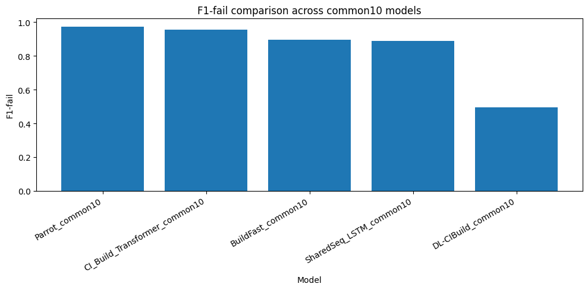

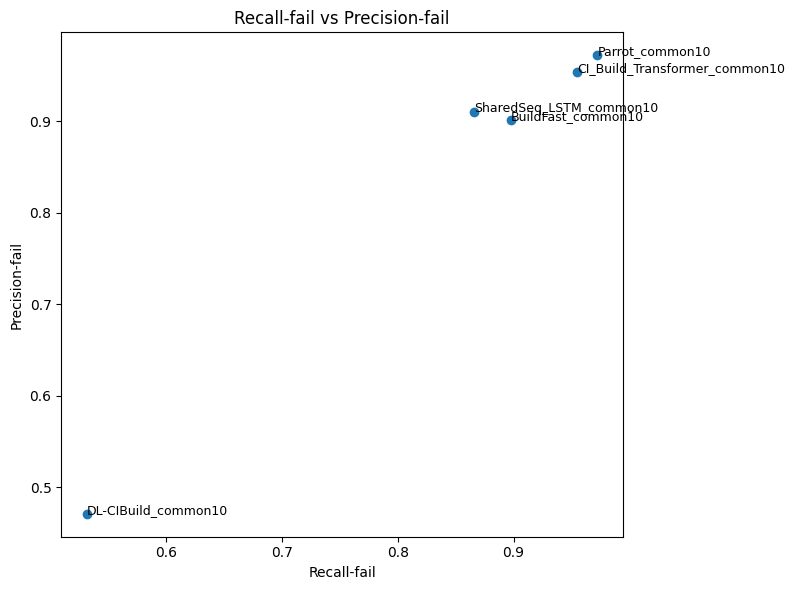

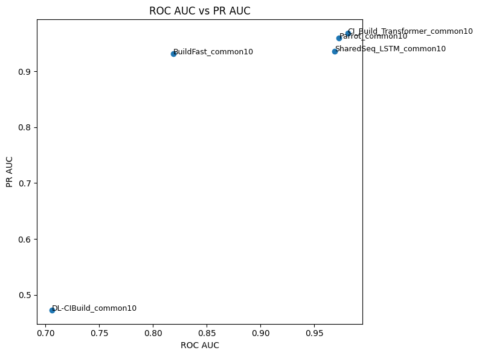

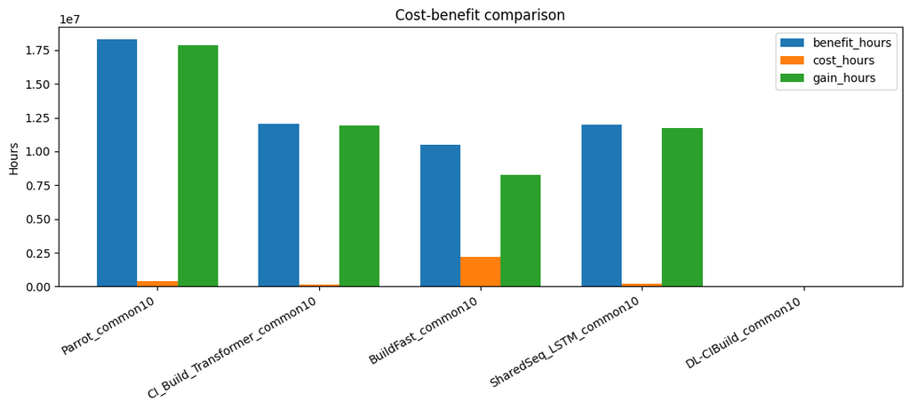

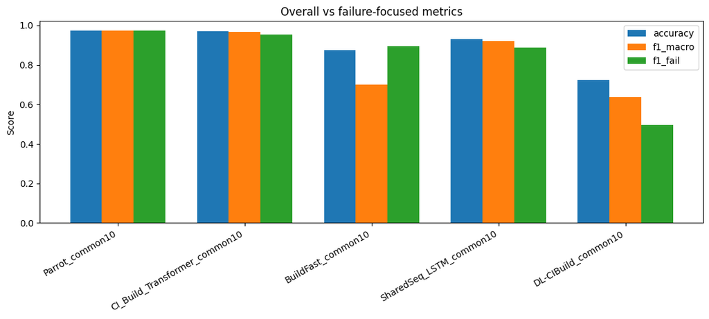

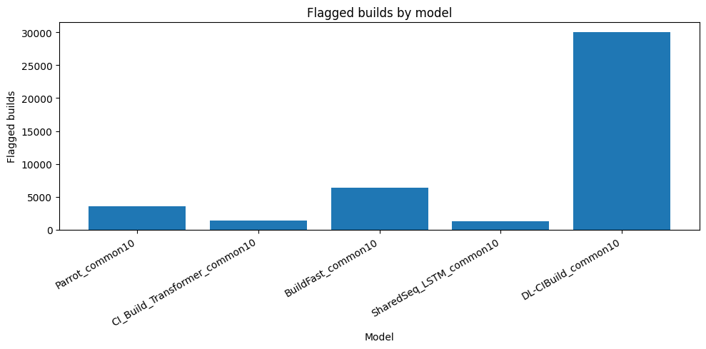

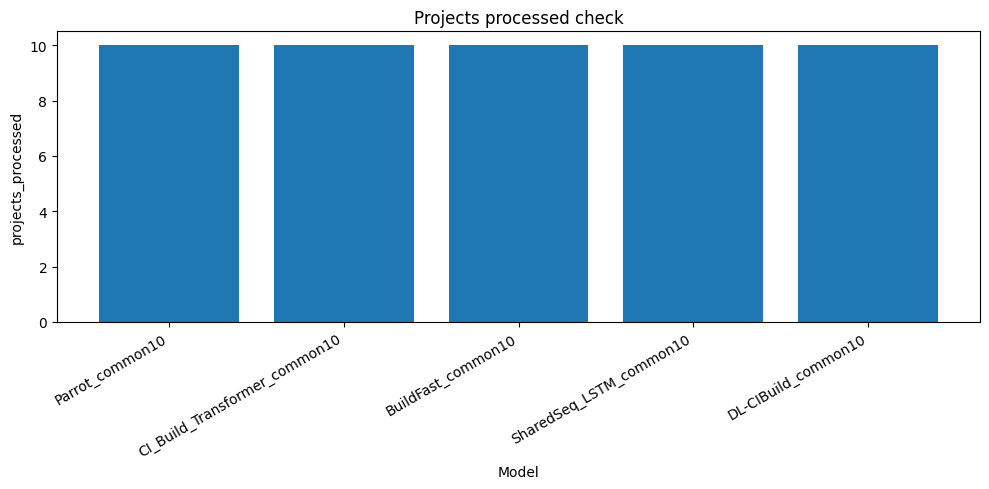

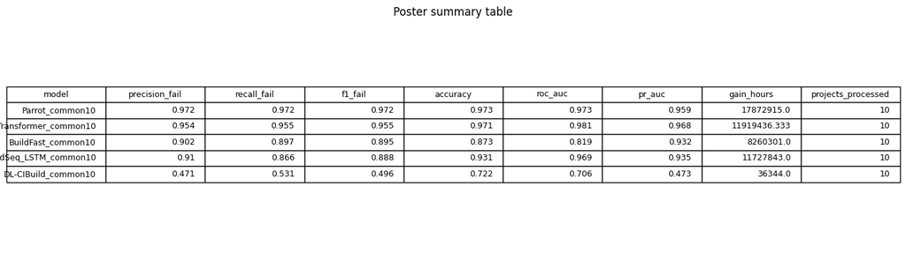

```
Saved plots to: outputs\poster_plots
```

```python
PLOT_DIR = OUTPUT_DIR / "poster_plots"
PLOT_DIR.mkdir(parents=True, exist_ok=True)

# -----------------------------
# 1. Main comparison bar chart
# -----------------------------
plot_df = results_df.copy()

fig, ax = plt.subplots(figsize=(10, 5))
ax.bar(plot_df["model"], plot_df["f1_fail"])
ax.set_title("F1-fail comparison across common10 models")
ax.set_ylabel("F1-fail")
ax.set_xlabel("Model")
plt.xticks(rotation=30, ha="right")
plt.tight_layout()
plt.savefig(PLOT_DIR / "01_f1_fail_bar.png", dpi=200, bbox_inches="tight")
plt.show()

# -----------------------------
# 2. Recall vs Precision scatter
# -----------------------------
fig, ax = plt.subplots(figsize=(8, 6))
ax.scatter(plot_df["recall_fail"], plot_df["precision_fail"])
for _, row in plot_df.iterrows():
    ax.annotate(row["model"], (row["recall_fail"], row["precision_fail"]), fontsize=9)
ax.set_title("Recall-fail vs Precision-fail")
ax.set_xlabel("Recall-fail")
ax.set_ylabel("Precision-fail")
plt.tight_layout()
plt.savefig(PLOT_DIR / "02_precision_vs_recall.png", dpi=200, bbox_inches="tight")
plt.show()

# -----------------------------
# 3. ROC AUC vs PR AUC scatter
# -----------------------------
fig, ax = plt.subplots(figsize=(8, 6))
ax.scatter(plot_df["roc_auc"], plot_df["pr_auc"])
for _, row in plot_df.iterrows():
    ax.annotate(row["model"], (row["roc_auc"], row["pr_auc"]), fontsize=9)
ax.set_title("ROC AUC vs PR AUC")
ax.set_xlabel("ROC AUC")
ax.set_ylabel("PR AUC")
plt.tight_layout()
plt.savefig(PLOT_DIR / "03_auc_vs_prauc.png", dpi=200, bbox_inches="tight")
plt.show()

# -----------------------------
# 4. Benefit / Cost / Gain grouped bars
# -----------------------------
cost_df = plot_df[["model", "benefit_hours", "cost_hours", "gain_hours"]].copy()
x = np.arange(len(cost_df))
w = 0.25

fig, ax = plt.subplots(figsize=(11, 5))
ax.bar(x - w, cost_df["benefit_hours"], width=w, label="benefit_hours")
ax.bar(x,     cost_df["cost_hours"],    width=w, label="cost_hours")
ax.bar(x + w, cost_df["gain_hours"],    width=w, label="gain_hours")
ax.set_xticks(x)
ax.set_xticklabels(cost_df["model"], rotation=30, ha="right")
ax.set_title("Cost-benefit comparison")
ax.set_ylabel("Hours")
ax.legend()
plt.tight_layout()
plt.savefig(PLOT_DIR / "04_cost_benefit_grouped.png", dpi=200, bbox_inches="tight")
plt.show()

# -----------------------------
# 5. Accuracy / F1_macro / F1_fail grouped bars
# -----------------------------
metric_df = plot_df[["model", "accuracy", "f1_macro", "f1_fail"]].copy()
x = np.arange(len(metric_df))
w = 0.25

fig, ax = plt.subplots(figsize=(11, 5))
ax.bar(x - w, metric_df["accuracy"], width=w, label="accuracy")
ax.bar(x,     metric_df["f1_macro"], width=w, label="f1_macro")
ax.bar(x + w, metric_df["f1_fail"],  width=w, label="f1_fail")
ax.set_xticks(x)
ax.set_xticklabels(metric_df["model"], rotation=30, ha="right")
ax.set_title("Overall vs failure-focused metrics")
ax.set_ylabel("Score")
ax.legend()
plt.tight_layout()
plt.savefig(PLOT_DIR / "05_metric_grouped.png", dpi=200, bbox_inches="tight")
plt.show()

# -----------------------------
# 6. Flagged builds bar chart
# -----------------------------
fig, ax = plt.subplots(figsize=(10, 5))
ax.bar(plot_df["model"], plot_df["flagged_builds"])
ax.set_title("Flagged builds by model")
ax.set_ylabel("Flagged builds")
ax.set_xlabel("Model")
plt.xticks(rotation=30, ha="right")
plt.tight_layout()
plt.savefig(PLOT_DIR / "06_flagged_builds_bar.png", dpi=200, bbox_inches="tight")
plt.show()

# -----------------------------
# 7. Projects processed check
# -----------------------------
fig, ax = plt.subplots(figsize=(10, 5))
ax.bar(plot_df["model"], plot_df["projects_processed"])
ax.set_title("Projects processed check")
ax.set_ylabel("projects_processed")
ax.set_xlabel("Model")
plt.xticks(rotation=30, ha="right")
plt.tight_layout()
plt.savefig(PLOT_DIR / "07_projects_processed_bar.png", dpi=200, bbox_inches="tight")
plt.show()

# -----------------------------
# 8. Poster summary table image
# -----------------------------
summary_cols = [
    "model", "precision_fail", "recall_fail", "f1_fail",
    "accuracy", "roc_auc", "pr_auc", "gain_hours", "projects_processed"
]
summary_table = plot_df[summary_cols].copy().round(3)

fig, ax = plt.subplots(figsize=(14, max(2, 0.6 * len(summary_table) + 1)))
ax.axis("off")
tbl = ax.table(
    cellText=summary_table.values,
    colLabels=summary_table.columns,
    loc="center"
)
tbl.auto_set_font_size(False)
tbl.set_fontsize(9)
tbl.scale(1, 1.3)
plt.title("Poster summary table")
plt.tight_layout()
plt.savefig(PLOT_DIR / "08_summary_table.png", dpi=200, bbox_inches="tight")
plt.show()

print("Saved plots to:", PLOT_DIR)
```

## Threats to validity: noisy CI labels and benchmark sensitivity

Travis-based historical build data can be noisy and heterogeneous. Some passing builds may hide ignored failures, some build outcomes can be misleading, and build pipelines vary in complexity. Another issue is benchmark sensitivity: model performance can look different depending on which project subset, preprocessing steps, and comparison setup are used. That is one reason I moved to a fair common10 benchmark in this notebook. So the results here should be interpreted as build-failure prediction performance on a noisy historical CI benchmark, not as perfect ground truth for real operational breakage.

## Transformer Demo: Real Held-Out Test Cases

This demo shows how my Transformer works on a real held-out test case from the common10 benchmark.

For each selected case, it shows:

- the project
- the recent build history given to the model
- the predicted probability of failure
- the final pass/fail decision
- the true outcome

This makes the model easier to explain as a real CI prediction tool instead of only showing a summary table.

```python
# rebuild grouped source for readable demo windows
grouped_seq_source = {
    proj: grp.reset_index(drop=True).copy()
    for proj, grp in seq_source.groupby(project_col, sort=False)
}

@torch.no_grad()
def predict_single_sequence(model, x_np, threshold, device=DEVICE):
    model.eval()
    xb = torch.tensor(x_np[None, :, :], dtype=torch.float32, device=device)
    logits = model(xb).squeeze(-1)
    prob = torch.sigmoid(logits).item()
    pred = int(prob >= threshold)
    return prob, pred

def show_transformer_demo(case_idx=0, n_rows_to_show=8):
    rec = meta_seq_test[case_idx]
    project_name = rec["project"]
    target_idx = rec["target_idx"]

    grp = grouped_seq_source[project_name]

    history_window = grp.iloc[target_idx-SEQ_LEN:target_idx].copy()
    target_row = grp.iloc[target_idx].copy()

    x_case = X_seq_test[case_idx]
    y_true = int(y_seq_test[case_idx])

    prob, pred = predict_single_sequence(
        demo_transformer_model,
        x_case,
        threshold=demo_transformer_threshold,
        device=DEVICE
    )

    decision_text = "FAIL" if pred == 1 else "PASS"
    true_text = "FAIL" if y_true == 1 else "PASS"

    print("=" * 90)
    print(f"Transformer Demo Case #{case_idx}")
    print(f"Project: {project_name}")
    print(f"Predicted probability of failure: {prob:.4f}")
    print(f"Prediction at threshold {demo_transformer_threshold:.2f}: {decision_text}")
    print(f"True outcome: {true_text}")
    print("=" * 90)

    cols_to_show = [c for c in [
        "label_fail",
        "prev_build_outcome",
        "prev_fail",
        "prev_failure_streak",
        "fail_rate_last_3",
        "fail_rate_last_5",
        "fail_rate_last_10",
        "duration_prev",
        "duration_mean_last_3",
        "duration_mean_last_5",
        "duration_mean_last_10",
        "duration_drift",
        "num_tests_failed",
        "num_tests_ran",
        "churn_additions",
        "churn_deletions",
        "files_changed",
        "flip_indicator",
    ] if c in history_window.columns]

    display(history_window[cols_to_show].tail(n_rows_to_show))

    print("Target row summary:")
    target_summary_cols = [c for c in cols_to_show if c in target_row.index]
    display(pd.DataFrame(target_row[target_summary_cols]).T)
```

```python
interact(
    show_transformer_demo,
    case_idx=widgets.IntSlider(
        value=0,
        min=0,
        max=len(X_seq_test) - 1,
        step=1,
        description="Test case"
    ),
    n_rows_to_show=widgets.IntSlider(
        value=8,
        min=5,
        max=min(SEQ_LEN, 15),
        step=1,
        description="Rows shown"
    )
)
```

```
interactive(children=(IntSlider(value=0, description='Test case', max=4336), IntSlider(value=8, description='R…
```

```
<function __main__.show_transformer_demo(case_idx=0, n_rows_to_show=8)>
```